# R 성능평가

Jang, Eunhee

2018년 6월 14일

### R 모델 성능평가

#### R 모델 성능평가가 중요한 이유?

어떤 주제를 배우는 가장 좋은 방법은 해당 주제를 다른 사람에게 가르치는 것인 것처럼 기계학습자를 가르치고 평가하는 과정은 지금까지 배운 방법들에 대한 더 깊은 통찰력을 제공한다.

> 머신러닝이 수행한 결과에 대한 공정한 평가를 통해 머신러닝이 앞으로도 **미래의 데이터에 대해 더 잘 분류하고 예측할 수 있도록 해주고**  
> 분류결과가 요행수로 맞힌게 아니다라는 것을 확신하게 해주며 **분류결과를 좀더 일반화 할 수 있기** 때문이다.

#### 정확도란?

정확도는 머신러닝이 맞거나 틀린 경우의 비율을 나타낸다.

#### 정확도가 성능을 측정하는데 충분치 않은 이유? 그렇다면 사용할 수 있는 성능 척도는 무엇?

> 암 판정하는 분류기가 99%의 정확도를 갖고 있다고 하면 1%의 오류율이 있기 때문에 어떤 데이터에 대해서는 오류를 범할 수 있게된다.  
> 그래서 정확도 만으로는 성능을 측정하는데 충분치 않다.  
> 분류기 성능을 측정하는 여러 방법이 있지만, 가장 좋은 측정 방법은 분류기가 의도된 목적에 맞게 성공했는지를 반영하는 것이다. 있는 그대로의 정확도보다 유용성에 대한 성능 척도를 정의하는 것이 중요하다.

### 목차

1. 혼동행렬을 사용한 성능 척도
2. 카파 통계량
3. 민감도와 특이도
4. 정밀도와 재현율
5. 성능 트레이드 오프 시각화(ROC 곡선)

#### C5.0 분류기의 예측확률을 출력해서 mail이 ham일 확률과 spam일 확률을 각각 확인하시오

```r
sms_results <- read.csv("C:/data/sms_results.csv")

head(sms_results)
```

```
##   actual_type predict_type prob_spam prob_ham
## 1         ham          ham   0.00000  1.00000
## 2         ham          ham   0.00000  1.00000
## 3         ham          ham   0.00016  0.99984
## 4         ham          ham   0.00004  0.99996
## 5        spam         spam   1.00000  0.00000
## 6         ham          ham   0.00020  0.99980
```

```r
subset(sms_results, prob_spam > 0.40 & prob_spam < 0.60)
```

```
##      actual_type predict_type prob_spam prob_ham
## 377         spam          ham   0.47536  0.52464
## 717          ham         spam   0.56188  0.43812
## 1311         ham         spam   0.57917  0.42083
```

```r
subset(sms_results, actual_type != predict_type)
```

```
##      actual_type predict_type prob_spam prob_ham
## 53          spam          ham   0.00071  0.99929
## 59          spam          ham   0.00156  0.99844
## 73          spam          ham   0.01708  0.98292
## 76          spam          ham   0.00851  0.99149
## 184         spam          ham   0.01243  0.98757
## 332         spam          ham   0.00003  0.99997
## 357         spam          ham   0.06244  0.93756
## 367         spam          ham   0.03452  0.96548
## 377         spam          ham   0.47536  0.52464
## 397         spam          ham   0.13223  0.86777
## 400         spam          ham   0.02740  0.97260
## 435         spam          ham   0.06493  0.93507
## 440         spam          ham   0.11007  0.88993
## 712         spam          ham   0.00252  0.99748
```

[output cut: 21 more lines]

predict 함수의 type 종류  
type = “prob” : C5.0(의사결정트리)에서 확률로 사용  
type = “raw” : 나이브베이즈 예측확률로 출력  
type = “class” : 확률없이 예측 class로 출력  
추가) type = “posterior”, type = “probability”

```r
table(sms_results$predict_type, sms_results$actual_type)
```

```
##
##         ham spam
##   ham  1203   31
##   spam    4  152
```

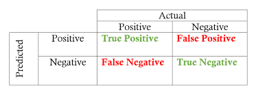

```
                TP + TN
정확도 = ---------------------
          TP + TN  + FP + FN
```

오류율 = 1- 정확도

```r
t <- table(sms_results$predict_type, sms_results$actual_type)
# 정확도
ac <- (t[1] + t[4]) / sum(t)
# 오류율
1- ac
```

```
## [1] 0.02517986
```

#### Caret 패키지를 이용하여 위의 혼동 행렬을 출력하시오

```r
library(caret)
confusionMatrix(sms_results$predict_type, sms_results$actual_type, positive = "spam")
```

```
## Confusion Matrix and Statistics
##
##           Reference
## Prediction  ham spam
##       ham  1203   31
##       spam    4  152
##
##                Accuracy : 0.9748
##                  95% CI : (0.9652, 0.9824)
##     No Information Rate : 0.8683
##     P-Value [Acc > NIR] : < 2.2e-16
##
##                   Kappa : 0.8825
##  Mcnemar's Test P-Value : 1.109e-05
##
##             Sensitivity : 0.8306
##             Specificity : 0.9967
##          Pos Pred Value : 0.9744
##          Neg Pred Value : 0.9749
##              Prevalence : 0.1317
##          Detection Rate : 0.1094
##    Detection Prevalence : 0.1122
##       Balanced Accuracy : 0.9136
##
##        'Positive' Class : spam
##
```

> 카파란(cohen’s Kappa Coefficient)?  
> 카테고리 정보에 대한 2명의 평가자의 일치도를 측정하는 통계적 지표

```
        Pr(a) - Pr(e)
k = ------------------------
          1  -  Pr(e)
```

Pr(a): 데이터에서 관찰된 2명의 평가자들의 일치 확률 Pr(e): 2명의 쳥가자들이 데이터로 부터 계산된 확률적으로 일지할 확률(우연히 일치할 확률)  
카파값은 0부터 최대 1까지 범위에 있으며, 1은 모델의 예측과 실제 값이 완벽하게 일치하는 경우를 나타낸다.

#### 예시: 시험에 응시한 학생이 100명이라고 할 때, 2명의 평가자가 합격, 불합격을 판정했다.

```r
test <- matrix(c(40,20,10,30), nrow=2)
colnames(test) <- c("합격", "불합격")
rownames(test) <- c("합격", "불합격")

test
```

```
##        합격 불합격
## 합격     40     10
## 불합격   20     30
```

> 설명: 평가자 A와 B 모두 40명에게 합격을, 30명에게 불합격을 주었다. Pr(a) 는 2명의 평가자들이 일치할 확률이므로 0.7이 된다.

```
            40 + 30
Pr(a) = -----------------
              100
```

```r
test <- rbind(test, c(sum(test[,1]),sum(test[,2])))
test <- cbind(test, c(sum(test[1,]), sum(test[2,]),sum(test)/2))
test
```

```
##        합격 불합격
## 합격     40     10  50
## 불합격   20     30  50
##          60     40 100
```

> Pr(e)를 계산하기 위해서는 평가자 A와 평가자 B의 각각의 합격과 불합격을 출 확률을 구해야 한다.  
> 평가자 A가 합격을 줄 확률 : 0.6 불합격을 줄 확률 : 0.4  
> 평가자 B가 합격을 줄 확률 : 0.5 불합격을 줄 확률 : 0.5  
> Pr(e) = (평가자 A가 합격을 줄 확률) X (평가자 B가 합격을 줄 확률) + (평가자 A가 불합격을 줄 확률)X(평가자 B가 불합격을 줄 확률)  
> = (0.6)X(0.5) + (0.4)X(0.5)  
> = 0.3 + 0.2  
> = 0.5

```
          Pr(a) - Pr(e)       0.7 + 0.5
  k  = ----------------- = --------------- = 0.4
           1 - Pr(e)           1  - 0.5
```

#### ham과 spam의 정확도가 97% 인데 kappa 지수는 어떻게 되는지 손으로 구하시오

```r
t <- table(sms_results$predict_type, sms_results$actual_type)
t
```

```
##
##         ham spam
##   ham  1203   31
##   spam    4  152
```

```r
PrA <- sum(t[1], t[4]) / sum(t)
PrE <- (sum(t[1:2]) / sum(t)) * (sum(t[1],t[3])/ sum(t)) + (sum(t[3:4])/sum(t)) * (sum(t[2],t[4]) / sum(t))
k <- (PrA - PrE) / (1 - PrE)
round(k,4)
```

```
## [1] 0.8825
```

#### 범주형 자료를 목적으로 분류하는 기계학습 알고리즘의 경우 정확도, 정밀도, 재현율, 통상적인 추적 모니터링 대상 측도가 된다.

[참고 site](https://statkclee.github.io/ml/ml-assessment.html)

#### 소극적 예측 vs 공격적 예측

- 소극적 예측: 암이라고 판단하는 것 자체를 소극적으로 봐서 확실한 경우가 아니면 암으로 판단하지 않는 것.  
  정밀도 ↑ & 재현율 ↓
- 공격적 예측: 조금만 의심이 가도 다 암이라고 판단  
  정밀도 ↓ & 재현율 ↑
- 특이성(Specificity): 예를 들어, 환자가 정상인데, 음성으로 검진될 확률.(거짓 중에 TN)  
  특이성=TN / (TN+FP)
- 민감도(sensitivity) : 환자가 정상인데, 정상으로 검진될 확률(TP)  
  민감도 = TP / (TP + FN)

```r
t <- table(sms_results$predict_type, sms_results$actual_type)
# 특이성
t[4] / (t[3]+t[4])
```

```
## [1] 0.8306011
```

```r
specificity(sms_results$predict_type, sms_results$actual_type, positive = "ham")
```

```
## [1] 0.8306011
```

```r
specificity(sms_results$predict_type, sms_results$actual_type, positive = "spam")
```

```
## [1] 0.8306011
```

```r
# 민감도
t[1] / (t[1]+t[2])
```

```
## [1] 0.996686
```

```r
sensitivity(sms_results$predict_type, sms_results$actual_type,positive="ham")
```

```
## [1] 0.996686
```

- 재현율(Recall) 혹은 민감도(Sensitivity): 예를 들어, 환자가 실제 암이 있는데, 양성으로 검진될 확률. 연관된 항목이 얼마나 많이 선택되었는지 측정.  
  재현율=TP/ (TP+FN)
- 정밀도(Precision): 선택된 항목이 얼마나 연관성이 있나를 측정, PPV(positive predictive value)로도 불림. 암환자 중에서 암으로 예측한 것의 비율  
  정밀도=TP / (TP+FP)

```r
t <- table(sms_results$predict_type, sms_results$actual_type)
# 재현율
t[1] / (t[1]+t[3])
```

```
## [1] 0.9748784
```

```r
recall <- sensitivity(sms_results$predict_type, sms_results$actual_type, positive = "ham")
# 정밀도
t[1] / (t[1]+t[2])
```

```
## [1] 0.996686
```

```r
precision <- posPredValue(sms_results$predict_type, sms_results$actual_type,positive="ham")
```

> 이를 **하나의 숫자로 바꾼것**이 F척도(F1 Score, F-Score, F-Measure)로 불리는 것으로 정밀도와 재현율을 조화평균한 것이다.

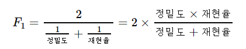

```r
f_measure_h <- (2*precision*recall)/(precision+recall)
# f_measure_s <-(2*P_S*S_P)/(P_S*S_P)
```

```r
# install.packages("ROCR")
library(ROCR)
```

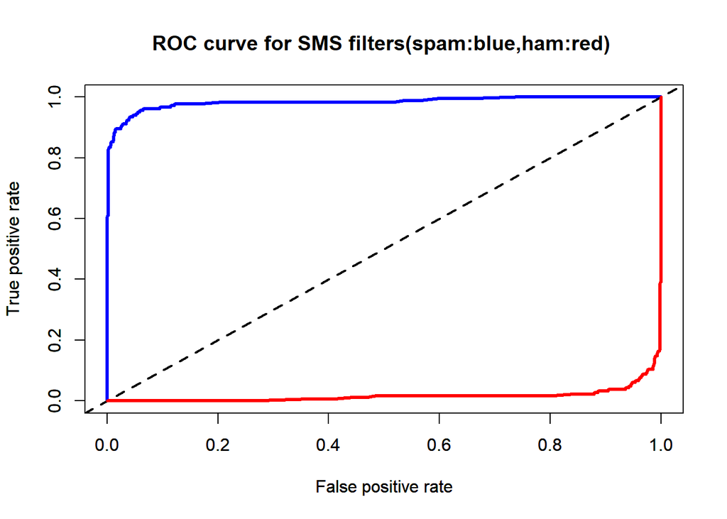

```r
pred_s <- prediction(predictions = sms_results$prob_spam, labels = sms_results$actual_type)
perf_s<-performance(pred_s,measure = "tpr",x.measure = "fpr")
plot(perf_s,main="ROC curve for SMS filters(spam:blue,ham:red) ",col="blue",lwd=3)
abline(a=0,b=1,lwd=2,lty=2)
par(new=T)
pred_h <-prediction(predictions = sms_results$prob_ham,labels = sms_results$actual_type)
perf_h <-performance(pred_h,measure = "tpr",x.measure = "fpr")
plot(perf_h,col="red",lwd=3)
```

```r
# graphics.off()
```

```r
confusionMatrix(sms_results$predict_type,
                sms_results$actual_type,
                positive = "spam", mode="prec_recall"  )
```

```
## Confusion Matrix and Statistics
##
##           Reference
## Prediction  ham spam
##       ham  1203   31
##       spam    4  152
##
##                Accuracy : 0.9748
##                  95% CI : (0.9652, 0.9824)
##     No Information Rate : 0.8683
##     P-Value [Acc > NIR] : < 2.2e-16
##
##                   Kappa : 0.8825
##  Mcnemar's Test P-Value : 1.109e-05
##
##               Precision : 0.9744
##                  Recall : 0.8306
##                      F1 : 0.8968
##              Prevalence : 0.1317
##          Detection Rate : 0.1094
##    Detection Prevalence : 0.1122
##       Balanced Accuracy : 0.9136
##
##        'Positive' Class : spam
##
```